# Optimal Treatment Analysis

## Outcome Variable

**Outcome Variable:** ever_stunted

## Predictor Variables

**Intervention Variable:** birthwt

**Adjustment Set:**

- arm
- sex
- W_mage
- meducyrs
- feducyrs
- vagbrth
- single
- brthmon
- W_parity
- delta_W_mage
- delta_meducyrs
- delta_feducyrs
- delta_vagbrth
- delta_single
- delta_brthmon
- delta_W_parity

## Stratifying Variables

The analysis was stratified on these variable(s):

- agecat
- studyid
- country

## Data Summary

| agecat | studyid | country | birthwt | ever_stunted | n_cell | n |
| --- | --- | --- | --- | --- | --- | --- |
| 0-24 months (no birth st.) | ki0047075b-MAL-ED | BANGLADESH | Normal or high birthweight | 0 | 92 | 212 |
| 0-24 months (no birth st.) | ki0047075b-MAL-ED | BANGLADESH | Normal or high birthweight | 1 | 96 | 212 |
| 0-24 months (no birth st.) | ki0047075b-MAL-ED | BANGLADESH | Low birth weight | 0 | 9 | 212 |
| 0-24 months (no birth st.) | ki0047075b-MAL-ED | BANGLADESH | Low birth weight | 1 | 15 | 212 |
| 0-24 months (no birth st.) | ki0047075b-MAL-ED | BRAZIL | Normal or high birthweight | 0 | 176 | 208 |
| 0-24 months (no birth st.) | ki0047075b-MAL-ED | BRAZIL | Normal or high birthweight | 1 | 29 | 208 |
| 0-24 months (no birth st.) | ki0047075b-MAL-ED | BRAZIL | Low birth weight | 0 | 3 | 208 |
| 0-24 months (no birth st.) | ki0047075b-MAL-ED | BRAZIL | Low birth weight | 1 | 0 | 208 |
| 0-24 months (no birth st.) | ki0047075b-MAL-ED | INDIA | Normal or high birthweight | 0 | 87 | 205 |
| 0-24 months (no birth st.) | ki0047075b-MAL-ED | INDIA | Normal or high birthweight | 1 | 97 | 205 |
| 0-24 months (no birth st.) | ki0047075b-MAL-ED | INDIA | Low birth weight | 0 | 11 | 205 |
| 0-24 months (no birth st.) | ki0047075b-MAL-ED | INDIA | Low birth weight | 1 | 10 | 205 |
| 0-24 months (no birth st.) | ki0047075b-MAL-ED | NEPAL | Normal or high birthweight | 0 | 151 | 206 |
| 0-24 months (no birth st.) | ki0047075b-MAL-ED | NEPAL | Normal or high birthweight | 1 | 47 | 206 |
| 0-24 months (no birth st.) | ki0047075b-MAL-ED | NEPAL | Low birth weight | 0 | 5 | 206 |
| 0-24 months (no birth st.) | ki0047075b-MAL-ED | NEPAL | Low birth weight | 1 | 3 | 206 |
| 0-24 months (no birth st.) | ki0047075b-MAL-ED | PERU | Normal or high birthweight | 0 | 114 | 264 |
| 0-24 months (no birth st.) | ki0047075b-MAL-ED | PERU | Normal or high birthweight | 1 | 148 | 264 |
| 0-24 months (no birth st.) | ki0047075b-MAL-ED | PERU | Low birth weight | 0 | 0 | 264 |
| 0-24 months (no birth st.) | ki0047075b-MAL-ED | PERU | Low birth weight | 1 | 2 | 264 |
| 0-24 months (no birth st.) | ki0047075b-MAL-ED | SOUTH AFRICA | Normal or high birthweight | 0 | 140 | 280 |
| 0-24 months (no birth st.) | ki0047075b-MAL-ED | SOUTH AFRICA | Normal or high birthweight | 1 | 130 | 280 |
| 0-24 months (no birth st.) | ki0047075b-MAL-ED | SOUTH AFRICA | Low birth weight | 0 | 3 | 280 |
| 0-24 months (no birth st.) | ki0047075b-MAL-ED | SOUTH AFRICA | Low birth weight | 1 | 7 | 280 |
| 0-24 months (no birth st.) | ki0047075b-MAL-ED | TANZANIA, UNITED REPUBLIC OF | Normal or high birthweight | 0 | 27 | 116 |
| 0-24 months (no birth st.) | ki0047075b-MAL-ED | TANZANIA, UNITED REPUBLIC OF | Normal or high birthweight | 1 | 88 | 116 |
| 0-24 months (no birth st.) | ki0047075b-MAL-ED | TANZANIA, UNITED REPUBLIC OF | Low birth weight | 0 | 1 | 116 |
| 0-24 months (no birth st.) | ki0047075b-MAL-ED | TANZANIA, UNITED REPUBLIC OF | Low birth weight | 1 | 0 | 116 |
| 0-24 months (no birth st.) | ki1000108-CMC-V-BCS-2002 | INDIA | Normal or high birthweight | 0 | 27 | 296 |
| 0-24 months (no birth st.) | ki1000108-CMC-V-BCS-2002 | INDIA | Normal or high birthweight | 1 | 255 | 296 |

[output cut: 314 more lines]

The following strata were considered:

- agecat: 0-24 months (no birth st.), studyid: ki0047075b-MAL-ED, country: BANGLADESH
- agecat: 0-24 months (no birth st.), studyid: ki0047075b-MAL-ED, country: BRAZIL
- agecat: 0-24 months (no birth st.), studyid: ki0047075b-MAL-ED, country: INDIA
- agecat: 0-24 months (no birth st.), studyid: ki0047075b-MAL-ED, country: NEPAL
- agecat: 0-24 months (no birth st.), studyid: ki0047075b-MAL-ED, country: PERU
- agecat: 0-24 months (no birth st.), studyid: ki0047075b-MAL-ED, country: SOUTH AFRICA
- agecat: 0-24 months (no birth st.), studyid: ki0047075b-MAL-ED, country: TANZANIA, UNITED REPUBLIC OF
- agecat: 0-24 months (no birth st.), studyid: ki1000108-CMC-V-BCS-2002, country: INDIA
- agecat: 0-24 months (no birth st.), studyid: ki1000108-IRC, country: INDIA
- agecat: 0-24 months (no birth st.), studyid: ki1000109-EE, country: PAKISTAN
- agecat: 0-24 months (no birth st.), studyid: ki1000109-ResPak, country: PAKISTAN
- agecat: 0-24 months (no birth st.), studyid: ki1000304b-SAS-CompFeed, country: INDIA
- agecat: 0-24 months (no birth st.), studyid: ki1017093-NIH-Birth, country: BANGLADESH
- agecat: 0-24 months (no birth st.), studyid: ki1017093b-PROVIDE, country: BANGLADESH
- agecat: 0-24 months (no birth st.), studyid: ki1017093c-NIH-Crypto, country: BANGLADESH
- agecat: 0-24 months (no birth st.), studyid: ki1066203-TanzaniaChild2, country: TANZANIA, UNITED REPUBLIC OF
- agecat: 0-24 months (no birth st.), studyid: ki1101329-Keneba, country: GAMBIA
- agecat: 0-24 months (no birth st.), studyid: ki1114097-CMIN, country: BANGLADESH
- agecat: 0-24 months (no birth st.), studyid: ki1114097-CMIN, country: BRAZIL
- agecat: 0-24 months (no birth st.), studyid: ki1114097-CMIN, country: GUINEA-BISSAU
- agecat: 0-24 months (no birth st.), studyid: ki1114097-CMIN, country: PERU
- agecat: 0-24 months (no birth st.), studyid: ki1114097-CONTENT, country: PERU
- agecat: 0-24 months (no birth st.), studyid: ki1119695-PROBIT, country: BELARUS
- agecat: 0-24 months (no birth st.), studyid: ki1126311-ZVITAMBO, country: ZIMBABWE
- agecat: 0-24 months (no birth st.), studyid: ki1135781-COHORTS, country: GUATEMALA
- agecat: 0-24 months (no birth st.), studyid: ki1135781-COHORTS, country: INDIA
- agecat: 0-24 months (no birth st.), studyid: ki1135781-COHORTS, country: PHILIPPINES
- agecat: 0-24 months (no birth st.), studyid: kiGH5241-JiVitA-3, country: BANGLADESH
- agecat: 0-24 months (no birth st.), studyid: kiGH5241-JiVitA-4, country: BANGLADESH
- agecat: 0-6 months (no birth st.), studyid: ki0047075b-MAL-ED, country: BANGLADESH
- agecat: 0-6 months (no birth st.), studyid: ki0047075b-MAL-ED, country: BRAZIL
- agecat: 0-6 months (no birth st.), studyid: ki0047075b-MAL-ED, country: INDIA
- agecat: 0-6 months (no birth st.), studyid: ki0047075b-MAL-ED, country: NEPAL
- agecat: 0-6 months (no birth st.), studyid: ki0047075b-MAL-ED, country: PERU
- agecat: 0-6 months (no birth st.), studyid: ki0047075b-MAL-ED, country: SOUTH AFRICA
- agecat: 0-6 months (no birth st.), studyid: ki0047075b-MAL-ED, country: TANZANIA, UNITED REPUBLIC OF
- agecat: 0-6 months (no birth st.), studyid: ki1000108-CMC-V-BCS-2002, country: INDIA
- agecat: 0-6 months (no birth st.), studyid: ki1000108-IRC, country: INDIA
- agecat: 0-6 months (no birth st.), studyid: ki1000109-EE, country: PAKISTAN
- agecat: 0-6 months (no birth st.), studyid: ki1000109-ResPak, country: PAKISTAN
- agecat: 0-6 months (no birth st.), studyid: ki1000304b-SAS-CompFeed, country: INDIA
- agecat: 0-6 months (no birth st.), studyid: ki1017093-NIH-Birth, country: BANGLADESH
- agecat: 0-6 months (no birth st.), studyid: ki1017093b-PROVIDE, country: BANGLADESH
- agecat: 0-6 months (no birth st.), studyid: ki1017093c-NIH-Crypto, country: BANGLADESH
- agecat: 0-6 months (no birth st.), studyid: ki1066203-TanzaniaChild2, country: TANZANIA, UNITED REPUBLIC OF
- agecat: 0-6 months (no birth st.), studyid: ki1101329-Keneba, country: GAMBIA
- agecat: 0-6 months (no birth st.), studyid: ki1114097-CMIN, country: BANGLADESH
- agecat: 0-6 months (no birth st.), studyid: ki1114097-CMIN, country: BRAZIL
- agecat: 0-6 months (no birth st.), studyid: ki1114097-CMIN, country: GUINEA-BISSAU
- agecat: 0-6 months (no birth st.), studyid: ki1114097-CMIN, country: PERU
- agecat: 0-6 months (no birth st.), studyid: ki1114097-CONTENT, country: PERU
- agecat: 0-6 months (no birth st.), studyid: ki1119695-PROBIT, country: BELARUS
- agecat: 0-6 months (no birth st.), studyid: ki1126311-ZVITAMBO, country: ZIMBABWE
- agecat: 0-6 months (no birth st.), studyid: ki1135781-COHORTS, country: GUATEMALA
- agecat: 0-6 months (no birth st.), studyid: ki1135781-COHORTS, country: INDIA
- agecat: 0-6 months (no birth st.), studyid: ki1135781-COHORTS, country: PHILIPPINES
- agecat: 0-6 months (no birth st.), studyid: kiGH5241-JiVitA-3, country: BANGLADESH
- agecat: 0-6 months (no birth st.), studyid: kiGH5241-JiVitA-4, country: BANGLADESH
- agecat: 6-24 months, studyid: ki0047075b-MAL-ED, country: BANGLADESH
- agecat: 6-24 months, studyid: ki0047075b-MAL-ED, country: BRAZIL
- agecat: 6-24 months, studyid: ki0047075b-MAL-ED, country: INDIA
- agecat: 6-24 months, studyid: ki0047075b-MAL-ED, country: NEPAL
- agecat: 6-24 months, studyid: ki0047075b-MAL-ED, country: PERU
- agecat: 6-24 months, studyid: ki0047075b-MAL-ED, country: SOUTH AFRICA
- agecat: 6-24 months, studyid: ki0047075b-MAL-ED, country: TANZANIA, UNITED REPUBLIC OF
- agecat: 6-24 months, studyid: ki1000108-CMC-V-BCS-2002, country: INDIA
- agecat: 6-24 months, studyid: ki1000108-IRC, country: INDIA
- agecat: 6-24 months, studyid: ki1000109-EE, country: PAKISTAN
- agecat: 6-24 months, studyid: ki1000109-ResPak, country: PAKISTAN
- agecat: 6-24 months, studyid: ki1000304b-SAS-CompFeed, country: INDIA
- agecat: 6-24 months, studyid: ki1017093-NIH-Birth, country: BANGLADESH
- agecat: 6-24 months, studyid: ki1017093b-PROVIDE, country: BANGLADESH
- agecat: 6-24 months, studyid: ki1017093c-NIH-Crypto, country: BANGLADESH
- agecat: 6-24 months, studyid: ki1066203-TanzaniaChild2, country: TANZANIA, UNITED REPUBLIC OF
- agecat: 6-24 months, studyid: ki1101329-Keneba, country: GAMBIA
- agecat: 6-24 months, studyid: ki1114097-CMIN, country: BRAZIL
- agecat: 6-24 months, studyid: ki1114097-CMIN, country: GUINEA-BISSAU
- agecat: 6-24 months, studyid: ki1114097-CMIN, country: PERU
- agecat: 6-24 months, studyid: ki1114097-CONTENT, country: PERU
- agecat: 6-24 months, studyid: ki1119695-PROBIT, country: BELARUS
- agecat: 6-24 months, studyid: ki1126311-ZVITAMBO, country: ZIMBABWE
- agecat: 6-24 months, studyid: ki1135781-COHORTS, country: GUATEMALA
- agecat: 6-24 months, studyid: ki1135781-COHORTS, country: INDIA
- agecat: 6-24 months, studyid: ki1135781-COHORTS, country: PHILIPPINES
- agecat: 6-24 months, studyid: kiGH5241-JiVitA-3, country: BANGLADESH
- agecat: 6-24 months, studyid: kiGH5241-JiVitA-4, country: BANGLADESH

### Dropped Strata

Some strata were dropped due to rare outcomes:

- agecat: 0-24 months (no birth st.), studyid: ki0047075b-MAL-ED, country: BRAZIL
- agecat: 0-24 months (no birth st.), studyid: ki0047075b-MAL-ED, country: NEPAL
- agecat: 0-24 months (no birth st.), studyid: ki0047075b-MAL-ED, country: PERU
- agecat: 0-24 months (no birth st.), studyid: ki0047075b-MAL-ED, country: SOUTH AFRICA
- agecat: 0-24 months (no birth st.), studyid: ki0047075b-MAL-ED, country: TANZANIA, UNITED REPUBLIC OF
- agecat: 0-24 months (no birth st.), studyid: ki1000108-CMC-V-BCS-2002, country: INDIA
- agecat: 0-24 months (no birth st.), studyid: ki1000109-EE, country: PAKISTAN
- agecat: 0-24 months (no birth st.), studyid: ki1000109-ResPak, country: PAKISTAN
- agecat: 0-24 months (no birth st.), studyid: ki1114097-CMIN, country: BANGLADESH
- agecat: 0-24 months (no birth st.), studyid: ki1114097-CMIN, country: BRAZIL
- agecat: 0-24 months (no birth st.), studyid: ki1114097-CMIN, country: GUINEA-BISSAU
- agecat: 0-24 months (no birth st.), studyid: ki1114097-CMIN, country: PERU
- agecat: 0-24 months (no birth st.), studyid: ki1114097-CONTENT, country: PERU
- agecat: 0-24 months (no birth st.), studyid: ki1119695-PROBIT, country: BELARUS
- agecat: 0-6 months (no birth st.), studyid: ki0047075b-MAL-ED, country: BRAZIL
- agecat: 0-6 months (no birth st.), studyid: ki0047075b-MAL-ED, country: NEPAL
- agecat: 0-6 months (no birth st.), studyid: ki0047075b-MAL-ED, country: PERU
- agecat: 0-6 months (no birth st.), studyid: ki0047075b-MAL-ED, country: SOUTH AFRICA
- agecat: 0-6 months (no birth st.), studyid: ki0047075b-MAL-ED, country: TANZANIA, UNITED REPUBLIC OF
- agecat: 0-6 months (no birth st.), studyid: ki1000108-CMC-V-BCS-2002, country: INDIA
- agecat: 0-6 months (no birth st.), studyid: ki1000109-ResPak, country: PAKISTAN
- agecat: 0-6 months (no birth st.), studyid: ki1114097-CMIN, country: BANGLADESH
- agecat: 0-6 months (no birth st.), studyid: ki1114097-CMIN, country: BRAZIL
- agecat: 0-6 months (no birth st.), studyid: ki1114097-CMIN, country: GUINEA-BISSAU
- agecat: 0-6 months (no birth st.), studyid: ki1114097-CMIN, country: PERU
- agecat: 0-6 months (no birth st.), studyid: ki1114097-CONTENT, country: PERU
- agecat: 0-6 months (no birth st.), studyid: ki1119695-PROBIT, country: BELARUS
- agecat: 6-24 months, studyid: ki0047075b-MAL-ED, country: BANGLADESH
- agecat: 6-24 months, studyid: ki0047075b-MAL-ED, country: BRAZIL
- agecat: 6-24 months, studyid: ki0047075b-MAL-ED, country: NEPAL
- agecat: 6-24 months, studyid: ki0047075b-MAL-ED, country: PERU
- agecat: 6-24 months, studyid: ki0047075b-MAL-ED, country: SOUTH AFRICA
- agecat: 6-24 months, studyid: ki0047075b-MAL-ED, country: TANZANIA, UNITED REPUBLIC OF
- agecat: 6-24 months, studyid: ki1000108-CMC-V-BCS-2002, country: INDIA
- agecat: 6-24 months, studyid: ki1000109-EE, country: PAKISTAN
- agecat: 6-24 months, studyid: ki1000109-ResPak, country: PAKISTAN
- agecat: 6-24 months, studyid: ki1114097-CMIN, country: BRAZIL
- agecat: 6-24 months, studyid: ki1114097-CMIN, country: GUINEA-BISSAU
- agecat: 6-24 months, studyid: ki1114097-CMIN, country: PERU
- agecat: 6-24 months, studyid: ki1114097-CONTENT, country: PERU
- agecat: 6-24 months, studyid: ki1119695-PROBIT, country: BELARUS
- agecat: 6-24 months, studyid: ki1135781-COHORTS, country: GUATEMALA

## Methods Detail

We’re interested in the causal parameters $E[Y_a]$ for all values of $a \in \mathcal{A}$. These parameters represent the mean outcome if, possibly contrary to fact, we intervened to set all units to have $A=a$. Under the randomization and positivity assumptions, these are identified by the statistical parameters $\psi_a=E_W[E_{Y|A,W}(Y|A=a,W)]$. In addition, we’re interested in the mean of $Y$, $E[Y]$ under no intervention (the observed mean). We will estimate these parameters by using SuperLearner to fit the relevant likelihood factors – $E_{Y|A,W}(Y|A=a,W)$ and $p(A=a|W)$, and then updating our likelihood fit using a joint TMLE.

For unadjusted analyses ($W=\{\}$), initial likelihoods were estimated using Lrnr_glm to estimate the simple $E(Y|A)$ and Lrnr_mean to estimate $p(A)$. For adjusted analyses, a small library containing Lrnr_glmnet, Lrnr_xgboost, and Lrnr_mean was used.

Having estimated these parameters, we will then use the delta method to estimate relative risks and attributable risks relative to a prespecified baseline level of $A$.

# Results Detail

## Results Plots

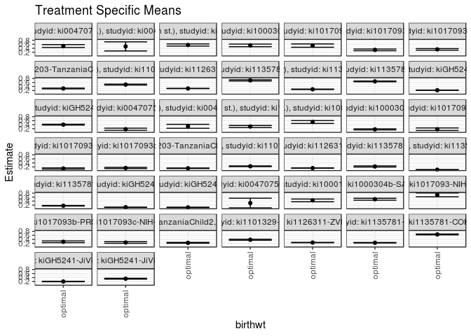

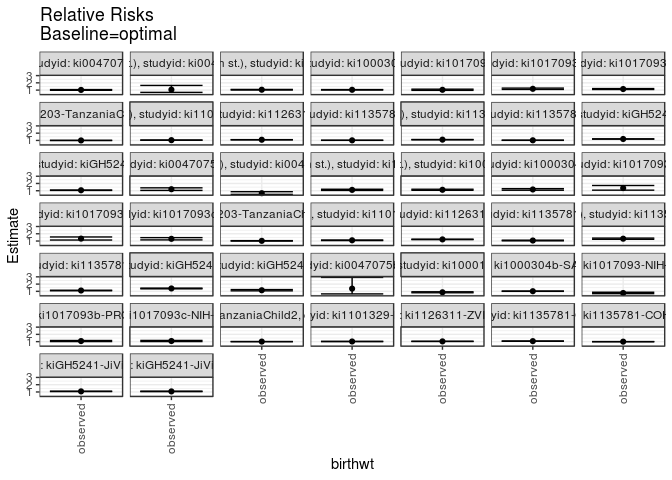

## Results Table

### Parameter: TSM

| agecat | studyid | country | intervention_level | baseline_level | estimate | ci_lower | ci_upper |
| --- | --- | --- | --- | --- | --- | --- | --- |
| 0-24 months (no birth st.) | ki0047075b-MAL-ED | BANGLADESH | optimal | NA | 0.5099329 | 0.4382349 | 0.5816309 |
| 0-24 months (no birth st.) | ki0047075b-MAL-ED | INDIA | optimal | NA | 0.4922281 | 0.2644103 | 0.7200459 |
| 0-24 months (no birth st.) | ki1000108-IRC | INDIA | optimal | NA | 0.5628227 | 0.5083063 | 0.6173391 |
| 0-24 months (no birth st.) | ki1000304b-SAS-CompFeed | INDIA | optimal | NA | 0.5426039 | 0.4771546 | 0.6080531 |
| 0-24 months (no birth st.) | ki1017093-NIH-Birth | BANGLADESH | optimal | NA | 0.5326225 | 0.4486799 | 0.6165651 |
| 0-24 months (no birth st.) | ki1017093b-PROVIDE | BANGLADESH | optimal | NA | 0.3183436 | 0.2750860 | 0.3616013 |
| 0-24 months (no birth st.) | ki1017093c-NIH-Crypto | BANGLADESH | optimal | NA | 0.3427082 | 0.3025514 | 0.3828651 |
| 0-24 months (no birth st.) | ki1066203-TanzaniaChild2 | TANZANIA, UNITED REPUBLIC OF | optimal | NA | 0.2990233 | 0.2793631 | 0.3186836 |
| 0-24 months (no birth st.) | ki1101329-Keneba | GAMBIA | optimal | NA | 0.4943461 | 0.4712581 | 0.5174341 |
| 0-24 months (no birth st.) | ki1126311-ZVITAMBO | ZIMBABWE | optimal | NA | 0.2986725 | 0.2902214 | 0.3071236 |
| 0-24 months (no birth st.) | ki1135781-COHORTS | GUATEMALA | optimal | NA | 0.7053977 | 0.6735229 | 0.7372725 |
| 0-24 months (no birth st.) | ki1135781-COHORTS | INDIA | optimal | NA | 0.2579391 | 0.2460090 | 0.2698691 |
| 0-24 months (no birth st.) | ki1135781-COHORTS | PHILIPPINES | optimal | NA | 0.6537662 | 0.6356633 | 0.6718691 |
| 0-24 months (no birth st.) | kiGH5241-JiVitA-3 | BANGLADESH | optimal | NA | 0.2124389 | 0.2044831 | 0.2203948 |
| 0-24 months (no birth st.) | kiGH5241-JiVitA-4 | BANGLADESH | optimal | NA | 0.4020828 | 0.3795981 | 0.4245676 |
| 0-6 months (no birth st.) | ki0047075b-MAL-ED | BANGLADESH | optimal | NA | 0.1716378 | 0.1179276 | 0.2253480 |
| 0-6 months (no birth st.) | ki0047075b-MAL-ED | INDIA | optimal | NA | 0.3188196 | 0.2199231 | 0.4177160 |
| 0-6 months (no birth st.) | ki1000108-IRC | INDIA | optimal | NA | 0.3078322 | 0.2562227 | 0.3594417 |
| 0-6 months (no birth st.) | ki1000109-EE | PAKISTAN | optimal | NA | 0.5336686 | 0.4617849 | 0.6055522 |
| 0-6 months (no birth st.) | ki1000304b-SAS-CompFeed | INDIA | optimal | NA | 0.1658644 | 0.1393959 | 0.1923329 |
| 0-6 months (no birth st.) | ki1017093-NIH-Birth | BANGLADESH | optimal | NA | 0.1736590 | 0.1095925 | 0.2377254 |
| 0-6 months (no birth st.) | ki1017093b-PROVIDE | BANGLADESH | optimal | NA | 0.1195720 | 0.0897114 | 0.1494326 |
| 0-6 months (no birth st.) | ki1017093c-NIH-Crypto | BANGLADESH | optimal | NA | 0.1458089 | 0.1159211 | 0.1756968 |
| 0-6 months (no birth st.) | ki1066203-TanzaniaChild2 | TANZANIA, UNITED REPUBLIC OF | optimal | NA | 0.1321677 | 0.1178081 | 0.1465273 |
| 0-6 months (no birth st.) | ki1101329-Keneba | GAMBIA | optimal | NA | 0.2309910 | 0.2109957 | 0.2509862 |
| 0-6 months (no birth st.) | ki1126311-ZVITAMBO | ZIMBABWE | optimal | NA | 0.1396926 | 0.1332167 | 0.1461685 |
| 0-6 months (no birth st.) | ki1135781-COHORTS | GUATEMALA | optimal | NA | 0.2214237 | 0.1920342 | 0.2508132 |
| 0-6 months (no birth st.) | ki1135781-COHORTS | INDIA | optimal | NA | 0.0596689 | 0.0531287 | 0.0662091 |
| 0-6 months (no birth st.) | ki1135781-COHORTS | PHILIPPINES | optimal | NA | 0.1692968 | 0.1549988 | 0.1835949 |
| 0-6 months (no birth st.) | kiGH5241-JiVitA-3 | BANGLADESH | optimal | NA | 0.0940782 | 0.0886061 | 0.0995503 |
| 0-6 months (no birth st.) | kiGH5241-JiVitA-4 | BANGLADESH | optimal | NA | 0.0851204 | 0.0728767 | 0.0973641 |
| 6-24 months | ki0047075b-MAL-ED | INDIA | optimal | NA | 0.3043238 | 0.0644335 | 0.5442140 |
| 6-24 months | ki1000108-IRC | INDIA | optimal | NA | 0.4363809 | 0.3687968 | 0.5039649 |
| 6-24 months | ki1000304b-SAS-CompFeed | INDIA | optimal | NA | 0.4933984 | 0.4452232 | 0.5415737 |
| 6-24 months | ki1017093-NIH-Birth | BANGLADESH | optimal | NA | 0.7104819 | 0.6162986 | 0.8046651 |
| 6-24 months | ki1017093b-PROVIDE | BANGLADESH | optimal | NA | 0.2770051 | 0.2330342 | 0.3209760 |
| 6-24 months | ki1017093c-NIH-Crypto | BANGLADESH | optimal | NA | 0.2419202 | 0.2018776 | 0.2819627 |
| 6-24 months | ki1066203-TanzaniaChild2 | TANZANIA, UNITED REPUBLIC OF | optimal | NA | 0.2247093 | 0.2038333 | 0.2455853 |
| 6-24 months | ki1101329-Keneba | GAMBIA | optimal | NA | 0.3801796 | 0.3546259 | 0.4057333 |
| 6-24 months | ki1126311-ZVITAMBO | ZIMBABWE | optimal | NA | 0.2380368 | 0.2284038 | 0.2476697 |
| 6-24 months | ki1135781-COHORTS | INDIA | optimal | NA | 0.2283094 | 0.2161024 | 0.2405165 |
| 6-24 months | ki1135781-COHORTS | PHILIPPINES | optimal | NA | 0.6446900 | 0.6232842 | 0.6660958 |
| 6-24 months | kiGH5241-JiVitA-3 | BANGLADESH | optimal | NA | 0.2009184 | 0.1908084 | 0.2110284 |
| 6-24 months | kiGH5241-JiVitA-4 | BANGLADESH | optimal | NA | 0.3425372 | 0.3202795 | 0.3647949 |

### Parameter: E(Y)

| agecat | studyid | country | intervention_level | baseline_level | estimate | ci_lower | ci_upper |
| --- | --- | --- | --- | --- | --- | --- | --- |
| 0-24 months (no birth st.) | ki0047075b-MAL-ED | BANGLADESH | observed | NA | 0.5235849 | 0.4561953 | 0.5909746 |
| 0-24 months (no birth st.) | ki0047075b-MAL-ED | INDIA | observed | NA | 0.5219512 | 0.4534049 | 0.5904975 |
| 0-24 months (no birth st.) | ki1000108-IRC | INDIA | observed | NA | 0.5921788 | 0.5412016 | 0.6431559 |
| 0-24 months (no birth st.) | ki1000304b-SAS-CompFeed | INDIA | observed | NA | 0.5661425 | 0.5076572 | 0.6246278 |
| 0-24 months (no birth st.) | ki1017093-NIH-Birth | BANGLADESH | observed | NA | 0.5549451 | 0.4825447 | 0.6273454 |
| 0-24 months (no birth st.) | ki1017093b-PROVIDE | BANGLADESH | observed | NA | 0.3753943 | 0.3376725 | 0.4131162 |
| 0-24 months (no birth st.) | ki1017093c-NIH-Crypto | BANGLADESH | observed | NA | 0.3935681 | 0.3560687 | 0.4310676 |
| 0-24 months (no birth st.) | ki1066203-TanzaniaChild2 | TANZANIA, UNITED REPUBLIC OF | observed | NA | 0.2985075 | 0.2794291 | 0.3175858 |
| 0-24 months (no birth st.) | ki1101329-Keneba | GAMBIA | observed | NA | 0.5129668 | 0.4906500 | 0.5352836 |
| 0-24 months (no birth st.) | ki1126311-ZVITAMBO | ZIMBABWE | observed | NA | 0.3259501 | 0.3177495 | 0.3341508 |
| 0-24 months (no birth st.) | ki1135781-COHORTS | GUATEMALA | observed | NA | 0.7142857 | 0.6835892 | 0.7449822 |
| 0-24 months (no birth st.) | ki1135781-COHORTS | INDIA | observed | NA | 0.2852591 | 0.2737975 | 0.2967207 |
| 0-24 months (no birth st.) | ki1135781-COHORTS | PHILIPPINES | observed | NA | 0.6646643 | 0.6472674 | 0.6820612 |
| 0-24 months (no birth st.) | kiGH5241-JiVitA-3 | BANGLADESH | observed | NA | 0.2540787 | 0.2462528 | 0.2619047 |
| 0-24 months (no birth st.) | kiGH5241-JiVitA-4 | BANGLADESH | observed | NA | 0.4282588 | 0.4077731 | 0.4487445 |
| 0-6 months (no birth st.) | ki0047075b-MAL-ED | BANGLADESH | observed | NA | 0.2075472 | 0.1528264 | 0.2622679 |
| 0-6 months (no birth st.) | ki0047075b-MAL-ED | INDIA | observed | NA | 0.2097561 | 0.1538871 | 0.2656251 |
| 0-6 months (no birth st.) | ki1000108-IRC | INDIA | observed | NA | 0.3435754 | 0.2943128 | 0.3928380 |
| 0-6 months (no birth st.) | ki1000109-EE | PAKISTAN | observed | NA | 0.6024096 | 0.5415000 | 0.6633193 |
| 0-6 months (no birth st.) | ki1000304b-SAS-CompFeed | INDIA | observed | NA | 0.1944444 | 0.1700545 | 0.2188344 |
| 0-6 months (no birth st.) | ki1017093-NIH-Birth | BANGLADESH | observed | NA | 0.2362637 | 0.1743796 | 0.2981478 |
| 0-6 months (no birth st.) | ki1017093b-PROVIDE | BANGLADESH | observed | NA | 0.1593060 | 0.1307970 | 0.1878149 |
| 0-6 months (no birth st.) | ki1017093c-NIH-Crypto | BANGLADESH | observed | NA | 0.1898928 | 0.1597870 | 0.2199986 |
| 0-6 months (no birth st.) | ki1066203-TanzaniaChild2 | TANZANIA, UNITED REPUBLIC OF | observed | NA | 0.1356852 | 0.1214076 | 0.1499628 |
| 0-6 months (no birth st.) | ki1101329-Keneba | GAMBIA | observed | NA | 0.2546652 | 0.2346549 | 0.2746755 |
| 0-6 months (no birth st.) | ki1126311-ZVITAMBO | ZIMBABWE | observed | NA | 0.1709340 | 0.1643442 | 0.1775239 |
| 0-6 months (no birth st.) | ki1135781-COHORTS | GUATEMALA | observed | NA | 0.2371007 | 0.2078658 | 0.2663357 |
| 0-6 months (no birth st.) | ki1135781-COHORTS | INDIA | observed | NA | 0.0788439 | 0.0719356 | 0.0857521 |
| 0-6 months (no birth st.) | ki1135781-COHORTS | PHILIPPINES | observed | NA | 0.1886926 | 0.1742747 | 0.2031105 |
| 0-6 months (no birth st.) | kiGH5241-JiVitA-3 | BANGLADESH | observed | NA | 0.1313499 | 0.1257126 | 0.1369873 |
| 0-6 months (no birth st.) | kiGH5241-JiVitA-4 | BANGLADESH | observed | NA | 0.0979962 | 0.0852560 | 0.1107365 |
| 6-24 months | ki0047075b-MAL-ED | INDIA | observed | NA | 0.4183007 | 0.3398819 | 0.4967194 |
| 6-24 months | ki1000108-IRC | INDIA | observed | NA | 0.3787234 | 0.3165730 | 0.4408738 |
| 6-24 months | ki1000304b-SAS-CompFeed | INDIA | observed | NA | 0.5018680 | 0.4570583 | 0.5466777 |
| 6-24 months | ki1017093-NIH-Birth | BANGLADESH | observed | NA | 0.5471698 | 0.4519599 | 0.6423797 |
| 6-24 months | ki1017093b-PROVIDE | BANGLADESH | observed | NA | 0.2997812 | 0.2577294 | 0.3418330 |
| 6-24 months | ki1017093c-NIH-Crypto | BANGLADESH | observed | NA | 0.2628458 | 0.2244546 | 0.3012371 |
| 6-24 months | ki1066203-TanzaniaChild2 | TANZANIA, UNITED REPUBLIC OF | observed | NA | 0.2265576 | 0.2059690 | 0.2471462 |
| 6-24 months | ki1101329-Keneba | GAMBIA | observed | NA | 0.3882759 | 0.3631823 | 0.4133694 |
| 6-24 months | ki1126311-ZVITAMBO | ZIMBABWE | observed | NA | 0.2463439 | 0.2368610 | 0.2558268 |
| 6-24 months | ki1135781-COHORTS | INDIA | observed | NA | 0.2440256 | 0.2322906 | 0.2557607 |
| 6-24 months | ki1135781-COHORTS | PHILIPPINES | observed | NA | 0.6435738 | 0.6230503 | 0.6640973 |
| 6-24 months | kiGH5241-JiVitA-3 | BANGLADESH | observed | NA | 0.2168548 | 0.2074258 | 0.2262838 |
| 6-24 months | kiGH5241-JiVitA-4 | BANGLADESH | observed | NA | 0.3682386 | 0.3473666 | 0.3891105 |

### Parameter: RR

| agecat | studyid | country | intervention_level | baseline_level | estimate | ci_lower | ci_upper |
| --- | --- | --- | --- | --- | --- | --- | --- |
| 0-24 months (no birth st.) | ki0047075b-MAL-ED | BANGLADESH | observed | optimal | 1.0267721 | 0.9793353 | 1.0765066 |
| 0-24 months (no birth st.) | ki0047075b-MAL-ED | INDIA | observed | optimal | 1.0603849 | 0.6840124 | 1.6438534 |
| 0-24 months (no birth st.) | ki1000108-IRC | INDIA | observed | optimal | 1.0521587 | 1.0138715 | 1.0918917 |
| 0-24 months (no birth st.) | ki1000304b-SAS-CompFeed | INDIA | observed | optimal | 1.0433808 | 1.0118933 | 1.0758482 |
| 0-24 months (no birth st.) | ki1017093-NIH-Birth | BANGLADESH | observed | optimal | 1.0419107 | 0.9650021 | 1.1249487 |
| 0-24 months (no birth st.) | ki1017093b-PROVIDE | BANGLADESH | observed | optimal | 1.1792110 | 1.0908192 | 1.2747654 |
| 0-24 months (no birth st.) | ki1017093c-NIH-Crypto | BANGLADESH | observed | optimal | 1.1484058 | 1.0856817 | 1.2147538 |
| 0-24 months (no birth st.) | ki1066203-TanzaniaChild2 | TANZANIA, UNITED REPUBLIC OF | observed | optimal | 0.9982749 | 0.9820016 | 1.0148178 |
| 0-24 months (no birth st.) | ki1101329-Keneba | GAMBIA | observed | optimal | 1.0376674 | 1.0250669 | 1.0504227 |
| 0-24 months (no birth st.) | ki1126311-ZVITAMBO | ZIMBABWE | observed | optimal | 1.0913295 | 1.0794311 | 1.1033591 |
| 0-24 months (no birth st.) | ki1135781-COHORTS | GUATEMALA | observed | optimal | 1.0126000 | 1.0036664 | 1.0216132 |
| 0-24 months (no birth st.) | ki1135781-COHORTS | INDIA | observed | optimal | 1.1059167 | 1.0841938 | 1.1280748 |
| 0-24 months (no birth st.) | ki1135781-COHORTS | PHILIPPINES | observed | optimal | 1.0166697 | 1.0102109 | 1.0231699 |
| 0-24 months (no birth st.) | kiGH5241-JiVitA-3 | BANGLADESH | observed | optimal | 1.1960083 | 1.1750329 | 1.2173582 |
| 0-24 months (no birth st.) | kiGH5241-JiVitA-4 | BANGLADESH | observed | optimal | 1.0651010 | 1.0389473 | 1.0919130 |
| 0-6 months (no birth st.) | ki0047075b-MAL-ED | BANGLADESH | observed | optimal | 1.2092158 | 1.0446015 | 1.3997710 |
| 0-6 months (no birth st.) | ki0047075b-MAL-ED | INDIA | observed | optimal | 0.6579147 | 0.4988064 | 0.8677752 |
| 0-6 months (no birth st.) | ki1000108-IRC | INDIA | observed | optimal | 1.1161126 | 1.0383183 | 1.1997356 |
| 0-6 months (no birth st.) | ki1000109-EE | PAKISTAN | observed | optimal | 1.1288085 | 1.0565888 | 1.2059647 |
| 0-6 months (no birth st.) | ki1000304b-SAS-CompFeed | INDIA | observed | optimal | 1.1723097 | 1.0707356 | 1.2835195 |
| 0-6 months (no birth st.) | ki1017093-NIH-Birth | BANGLADESH | observed | optimal | 1.3605041 | 1.0765859 | 1.7192975 |
| 0-6 months (no birth st.) | ki1017093b-PROVIDE | BANGLADESH | observed | optimal | 1.3323020 | 1.1381143 | 1.5596225 |
| 0-6 months (no birth st.) | ki1017093c-NIH-Crypto | BANGLADESH | observed | optimal | 1.3023399 | 1.1573246 | 1.4655260 |
| 0-6 months (no birth st.) | ki1066203-TanzaniaChild2 | TANZANIA, UNITED REPUBLIC OF | observed | optimal | 1.0266140 | 1.0035708 | 1.0501864 |
| 0-6 months (no birth st.) | ki1101329-Keneba | GAMBIA | observed | optimal | 1.1024899 | 1.0688005 | 1.1372413 |
| 0-6 months (no birth st.) | ki1126311-ZVITAMBO | ZIMBABWE | observed | optimal | 1.2236443 | 1.1956511 | 1.2522930 |
| 0-6 months (no birth st.) | ki1135781-COHORTS | GUATEMALA | observed | optimal | 1.0708012 | 1.0258851 | 1.1176838 |
| 0-6 months (no birth st.) | ki1135781-COHORTS | INDIA | observed | optimal | 1.3213549 | 1.2412176 | 1.4066661 |
| 0-6 months (no birth st.) | ki1135781-COHORTS | PHILIPPINES | observed | optimal | 1.1145666 | 1.0798785 | 1.1503691 |
| 0-6 months (no birth st.) | kiGH5241-JiVitA-3 | BANGLADESH | observed | optimal | 1.3961781 | 1.3485505 | 1.4454878 |
| 0-6 months (no birth st.) | kiGH5241-JiVitA-4 | BANGLADESH | observed | optimal | 1.1512660 | 1.0662556 | 1.2430540 |
| 6-24 months | ki0047075b-MAL-ED | INDIA | observed | optimal | 1.3745250 | 0.6473698 | 2.9184539 |
| 6-24 months | ki1000108-IRC | INDIA | observed | optimal | 0.8678735 | 0.8003693 | 0.9410712 |
| 6-24 months | ki1000304b-SAS-CompFeed | INDIA | observed | optimal | 1.0171658 | 0.9944856 | 1.0403633 |
| 6-24 months | ki1017093-NIH-Birth | BANGLADESH | observed | optimal | 0.7701390 | 0.6806150 | 0.8714385 |
| 6-24 months | ki1017093b-PROVIDE | BANGLADESH | observed | optimal | 1.0822225 | 1.0144855 | 1.1544824 |
| 6-24 months | ki1017093c-NIH-Crypto | BANGLADESH | observed | optimal | 1.0864983 | 1.0136459 | 1.1645867 |
| 6-24 months | ki1066203-TanzaniaChild2 | TANZANIA, UNITED REPUBLIC OF | observed | optimal | 1.0082254 | 0.9941697 | 1.0224798 |
| 6-24 months | ki1101329-Keneba | GAMBIA | observed | optimal | 1.0212960 | 1.0061180 | 1.0367030 |
| 6-24 months | ki1126311-ZVITAMBO | ZIMBABWE | observed | optimal | 1.0348986 | 1.0237251 | 1.0461940 |
| 6-24 months | ki1135781-COHORTS | INDIA | observed | optimal | 1.0688373 | 1.0466107 | 1.0915360 |
| 6-24 months | ki1135781-COHORTS | PHILIPPINES | observed | optimal | 0.9982687 | 0.9868264 | 1.0098436 |
| 6-24 months | kiGH5241-JiVitA-3 | BANGLADESH | observed | optimal | 1.0793178 | 1.0543189 | 1.1049094 |
| 6-24 months | kiGH5241-JiVitA-4 | BANGLADESH | observed | optimal | 1.0750322 | 1.0476906 | 1.1030874 |

### Parameter: PAR

| agecat | studyid | country | intervention_level | baseline_level | estimate | ci_lower | ci_upper |
| --- | --- | --- | --- | --- | --- | --- | --- |
| 0-24 months (no birth st.) | ki0047075b-MAL-ED | BANGLADESH | optimal | NA | 0.0136520 | -0.0103929 | 0.0376969 |
| 0-24 months (no birth st.) | ki0047075b-MAL-ED | INDIA | optimal | NA | 0.0297231 | -0.1859490 | 0.2453953 |
| 0-24 months (no birth st.) | ki1000108-IRC | INDIA | optimal | NA | 0.0293561 | 0.0085774 | 0.0501348 |
| 0-24 months (no birth st.) | ki1000304b-SAS-CompFeed | INDIA | optimal | NA | 0.0235386 | 0.0078912 | 0.0391861 |
| 0-24 months (no birth st.) | ki1017093-NIH-Birth | BANGLADESH | optimal | NA | 0.0223226 | -0.0183410 | 0.0629861 |
| 0-24 months (no birth st.) | ki1017093b-PROVIDE | BANGLADESH | optimal | NA | 0.0570507 | 0.0324251 | 0.0816762 |
| 0-24 months (no birth st.) | ki1017093c-NIH-Crypto | BANGLADESH | optimal | NA | 0.0508599 | 0.0316790 | 0.0700408 |
| 0-24 months (no birth st.) | ki1066203-TanzaniaChild2 | TANZANIA, UNITED REPUBLIC OF | optimal | NA | -0.0005158 | -0.0054301 | 0.0043984 |
| 0-24 months (no birth st.) | ki1101329-Keneba | GAMBIA | optimal | NA | 0.0186207 | 0.0126331 | 0.0246083 |
| 0-24 months (no birth st.) | ki1126311-ZVITAMBO | ZIMBABWE | optimal | NA | 0.0272776 | 0.0239906 | 0.0305647 |
| 0-24 months (no birth st.) | ki1135781-COHORTS | GUATEMALA | optimal | NA | 0.0088880 | 0.0026840 | 0.0150921 |
| 0-24 months (no birth st.) | ki1135781-COHORTS | INDIA | optimal | NA | 0.0273200 | 0.0221758 | 0.0324643 |
| 0-24 months (no birth st.) | ki1135781-COHORTS | PHILIPPINES | optimal | NA | 0.0108981 | 0.0067569 | 0.0150393 |
| 0-24 months (no birth st.) | kiGH5241-JiVitA-3 | BANGLADESH | optimal | NA | 0.0416398 | 0.0378281 | 0.0454515 |
| 0-24 months (no birth st.) | kiGH5241-JiVitA-4 | BANGLADESH | optimal | NA | 0.0261760 | 0.0162175 | 0.0361345 |
| 0-6 months (no birth st.) | ki0047075b-MAL-ED | BANGLADESH | optimal | NA | 0.0359093 | 0.0098829 | 0.0619358 |
| 0-6 months (no birth st.) | ki0047075b-MAL-ED | INDIA | optimal | NA | -0.1090635 | -0.1918206 | -0.0263064 |
| 0-6 months (no birth st.) | ki1000108-IRC | INDIA | optimal | NA | 0.0357432 | 0.0134883 | 0.0579981 |
| 0-6 months (no birth st.) | ki1000109-EE | PAKISTAN | optimal | NA | 0.0687411 | 0.0346364 | 0.1028458 |
| 0-6 months (no birth st.) | ki1000304b-SAS-CompFeed | INDIA | optimal | NA | 0.0285800 | 0.0133608 | 0.0437993 |
| 0-6 months (no birth st.) | ki1017093-NIH-Birth | BANGLADESH | optimal | NA | 0.0626048 | 0.0203810 | 0.1048285 |
| 0-6 months (no birth st.) | ki1017093b-PROVIDE | BANGLADESH | optimal | NA | 0.0397340 | 0.0202621 | 0.0592059 |
| 0-6 months (no birth st.) | ki1017093c-NIH-Crypto | BANGLADESH | optimal | NA | 0.0440839 | 0.0260228 | 0.0621450 |
| 0-6 months (no birth st.) | ki1066203-TanzaniaChild2 | TANZANIA, UNITED REPUBLIC OF | optimal | NA | 0.0035175 | 0.0005110 | 0.0065240 |
| 0-6 months (no birth st.) | ki1101329-Keneba | GAMBIA | optimal | NA | 0.0236742 | 0.0164008 | 0.0309477 |
| 0-6 months (no birth st.) | ki1126311-ZVITAMBO | ZIMBABWE | optimal | NA | 0.0312415 | 0.0278730 | 0.0346100 |
| 0-6 months (no birth st.) | ki1135781-COHORTS | GUATEMALA | optimal | NA | 0.0156771 | 0.0060979 | 0.0252562 |
| 0-6 months (no birth st.) | ki1135781-COHORTS | INDIA | optimal | NA | 0.0191749 | 0.0151405 | 0.0232093 |
| 0-6 months (no birth st.) | ki1135781-COHORTS | PHILIPPINES | optimal | NA | 0.0193958 | 0.0139295 | 0.0248620 |
| 0-6 months (no birth st.) | kiGH5241-JiVitA-3 | BANGLADESH | optimal | NA | 0.0372717 | 0.0338017 | 0.0407417 |
| 0-6 months (no birth st.) | kiGH5241-JiVitA-4 | BANGLADESH | optimal | NA | 0.0128758 | 0.0059668 | 0.0197848 |
| 6-24 months | ki0047075b-MAL-ED | INDIA | optimal | NA | 0.1139769 | -0.1146973 | 0.3426510 |
| 6-24 months | ki1000108-IRC | INDIA | optimal | NA | -0.0576575 | -0.0908092 | -0.0245058 |
| 6-24 months | ki1000304b-SAS-CompFeed | INDIA | optimal | NA | 0.0084696 | -0.0024830 | 0.0194222 |
| 6-24 months | ki1017093-NIH-Birth | BANGLADESH | optimal | NA | -0.1633121 | -0.2359062 | -0.0907179 |
| 6-24 months | ki1017093b-PROVIDE | BANGLADESH | optimal | NA | 0.0227761 | 0.0048233 | 0.0407288 |
| 6-24 months | ki1017093c-NIH-Crypto | BANGLADESH | optimal | NA | 0.0209257 | 0.0040448 | 0.0378066 |
| 6-24 months | ki1066203-TanzaniaChild2 | TANZANIA, UNITED REPUBLIC OF | optimal | NA | 0.0018483 | -0.0012993 | 0.0049960 |
| 6-24 months | ki1101329-Keneba | GAMBIA | optimal | NA | 0.0080963 | 0.0024114 | 0.0137812 |
| 6-24 months | ki1126311-ZVITAMBO | ZIMBABWE | optimal | NA | 0.0083071 | 0.0057179 | 0.0108964 |
| 6-24 months | ki1135781-COHORTS | INDIA | optimal | NA | 0.0157162 | 0.0108980 | 0.0205344 |
| 6-24 months | ki1135781-COHORTS | PHILIPPINES | optimal | NA | -0.0011162 | -0.0085462 | 0.0063138 |
| 6-24 months | kiGH5241-JiVitA-3 | BANGLADESH | optimal | NA | 0.0159364 | 0.0112085 | 0.0206643 |
| 6-24 months | kiGH5241-JiVitA-4 | BANGLADESH | optimal | NA | 0.0257013 | 0.0169292 | 0.0344734 |

### Parameter: PAF

| agecat | studyid | country | intervention_level | baseline_level | estimate | ci_lower | ci_upper |
| --- | --- | --- | --- | --- | --- | --- | --- |
| 0-24 months (no birth st.) | ki0047075b-MAL-ED | BANGLADESH | optimal | NA | 0.0260740 | -0.0211007 | 0.0710693 |
| 0-24 months (no birth st.) | ki0047075b-MAL-ED | INDIA | optimal | NA | 0.0569462 | -0.4619617 | 0.3916732 |
| 0-24 months (no birth st.) | ki1000108-IRC | INDIA | optimal | NA | 0.0495730 | 0.0136817 | 0.0841582 |
| 0-24 months (no birth st.) | ki1000304b-SAS-CompFeed | INDIA | optimal | NA | 0.0415772 | 0.0117535 | 0.0705008 |
| 0-24 months (no birth st.) | ki1017093-NIH-Birth | BANGLADESH | optimal | NA | 0.0402248 | -0.0362671 | 0.1110705 |
| 0-24 months (no birth st.) | ki1017093b-PROVIDE | BANGLADESH | optimal | NA | 0.1519754 | 0.0832578 | 0.2155420 |
| 0-24 months (no birth st.) | ki1017093c-NIH-Crypto | BANGLADESH | optimal | NA | 0.1292277 | 0.0789197 | 0.1767879 |
| 0-24 months (no birth st.) | ki1066203-TanzaniaChild2 | TANZANIA, UNITED REPUBLIC OF | optimal | NA | -0.0017281 | -0.0183283 | 0.0146015 |
| 0-24 months (no birth st.) | ki1101329-Keneba | GAMBIA | optimal | NA | 0.0363001 | 0.0244539 | 0.0480023 |
| 0-24 months (no birth st.) | ki1126311-ZVITAMBO | ZIMBABWE | optimal | NA | 0.0836865 | 0.0735861 | 0.0936767 |
| 0-24 months (no birth st.) | ki1135781-COHORTS | GUATEMALA | optimal | NA | 0.0124433 | 0.0036530 | 0.0211560 |
| 0-24 months (no birth st.) | ki1135781-COHORTS | INDIA | optimal | NA | 0.0957727 | 0.0776556 | 0.1135340 |
| 0-24 months (no birth st.) | ki1135781-COHORTS | PHILIPPINES | optimal | NA | 0.0163964 | 0.0101076 | 0.0226452 |
| 0-24 months (no birth st.) | kiGH5241-JiVitA-3 | BANGLADESH | optimal | NA | 0.1638854 | 0.1489600 | 0.1785491 |
| 0-24 months (no birth st.) | kiGH5241-JiVitA-4 | BANGLADESH | optimal | NA | 0.0611219 | 0.0374873 | 0.0841761 |
| 0-6 months (no birth st.) | ki0047075b-MAL-ED | BANGLADESH | optimal | NA | 0.1730177 | 0.0426971 | 0.2855974 |
| 0-6 months (no birth st.) | ki0047075b-MAL-ED | INDIA | optimal | NA | -0.5199538 | -1.0047860 | -0.1523722 |
| 0-6 months (no birth st.) | ki1000108-IRC | INDIA | optimal | NA | 0.1040331 | 0.0369042 | 0.1664830 |
| 0-6 months (no birth st.) | ki1000109-EE | PAKISTAN | optimal | NA | 0.1141102 | 0.0535580 | 0.1707883 |
| 0-6 months (no birth st.) | ki1000304b-SAS-CompFeed | INDIA | optimal | NA | 0.1469831 | 0.0660626 | 0.2208922 |
| 0-6 months (no birth st.) | ki1017093-NIH-Birth | BANGLADESH | optimal | NA | 0.2649783 | 0.0711377 | 0.4183671 |
| 0-6 months (no birth st.) | ki1017093b-PROVIDE | BANGLADESH | optimal | NA | 0.2494194 | 0.1213536 | 0.3588192 |
| 0-6 months (no birth st.) | ki1017093c-NIH-Crypto | BANGLADESH | optimal | NA | 0.2321513 | 0.1359382 | 0.3176511 |
| 0-6 months (no birth st.) | ki1066203-TanzaniaChild2 | TANZANIA, UNITED REPUBLIC OF | optimal | NA | 0.0259241 | 0.0035581 | 0.0477881 |
| 0-6 months (no birth st.) | ki1101329-Keneba | GAMBIA | optimal | NA | 0.0929622 | 0.0643717 | 0.1206791 |
| 0-6 months (no birth st.) | ki1126311-ZVITAMBO | ZIMBABWE | optimal | NA | 0.1827691 | 0.1636356 | 0.2014648 |
| 0-6 months (no birth st.) | ki1135781-COHORTS | GUATEMALA | optimal | NA | 0.0661198 | 0.0252320 | 0.1052925 |
| 0-6 months (no birth st.) | ki1135781-COHORTS | INDIA | optimal | NA | 0.2432010 | 0.1943395 | 0.2890992 |
| 0-6 months (no birth st.) | ki1135781-COHORTS | PHILIPPINES | optimal | NA | 0.1027903 | 0.0739699 | 0.1307138 |
| 0-6 months (no birth st.) | kiGH5241-JiVitA-3 | BANGLADESH | optimal | NA | 0.2837590 | 0.2584631 | 0.3081920 |
| 0-6 months (no birth st.) | kiGH5241-JiVitA-4 | BANGLADESH | optimal | NA | 0.1313910 | 0.0621386 | 0.1955297 |
| 6-24 months | ki0047075b-MAL-ED | INDIA | optimal | NA | 0.2724759 | -0.5447121 | 0.6573528 |
| 6-24 months | ki1000108-IRC | INDIA | optimal | NA | -0.1522416 | -0.2494232 | -0.0626189 |
| 6-24 months | ki1000304b-SAS-CompFeed | INDIA | optimal | NA | 0.0168761 | -0.0055450 | 0.0387973 |
| 6-24 months | ki1017093-NIH-Birth | BANGLADESH | optimal | NA | -0.2984669 | -0.4692595 | -0.1475278 |
| 6-24 months | ki1017093b-PROVIDE | BANGLADESH | optimal | NA | 0.0759756 | 0.0142787 | 0.1338109 |
| 6-24 months | ki1017093c-NIH-Crypto | BANGLADESH | optimal | NA | 0.0796120 | 0.0134622 | 0.1413262 |
| 6-24 months | ki1066203-TanzaniaChild2 | TANZANIA, UNITED REPUBLIC OF | optimal | NA | 0.0081583 | -0.0058645 | 0.0219856 |
| 6-24 months | ki1101329-Keneba | GAMBIA | optimal | NA | 0.0208519 | 0.0060808 | 0.0354035 |
| 6-24 months | ki1126311-ZVITAMBO | ZIMBABWE | optimal | NA | 0.0337217 | 0.0231753 | 0.0441543 |
| 6-24 months | ki1135781-COHORTS | INDIA | optimal | NA | 0.0644039 | 0.0445349 | 0.0838598 |
| 6-24 months | ki1135781-COHORTS | PHILIPPINES | optimal | NA | -0.0017343 | -0.0133495 | 0.0097477 |
| 6-24 months | kiGH5241-JiVitA-3 | BANGLADESH | optimal | NA | 0.0734888 | 0.0515203 | 0.0949484 |
| 6-24 months | kiGH5241-JiVitA-4 | BANGLADESH | optimal | NA | 0.0697953 | 0.0455198 | 0.0934535 |